# Moneyball analysis in R.

Zauad Shahreer Abeer

April 22, 2018

## Introduction

The purpose of this assignment is to analyze baseball team data from 1871 to 2006 in order to predict the number of wins that a team will register in a regular season. Simple multivariate regression models will be used for the purpose. The models will be generated using variable selections techniques such as Forward, Backward or Stepwise selection. The best model will be selected and will be further analyzed to see if predictions can be made or further analysis is necessary.

## TASK 1 - Development of base model

### EDA and data cleaning

At first, let’s get a feel of the data

```
## 'data.frame':    2276 obs. of  17 variables:
##  $ INDEX           : int  1 2 3 4 5 6 7 8 11 12 ...
##  $ TARGET_WINS     : int  39 70 86 70 82 75 80 85 86 76 ...
##  $ TEAM_BATTING_H  : int  1445 1339 1377 1387 1297 1279 1244 1273 1391 1271 ...
##  $ TEAM_BATTING_2B : int  194 219 232 209 186 200 179 171 197 213 ...
##  $ TEAM_BATTING_3B : int  39 22 35 38 27 36 54 37 40 18 ...
##  $ TEAM_BATTING_HR : int  13 190 137 96 102 92 122 115 114 96 ...
##  $ TEAM_BATTING_BB : int  143 685 602 451 472 443 525 456 447 441 ...
##  $ TEAM_BATTING_SO : int  842 1075 917 922 920 973 1062 1027 922 827 ...
##  $ TEAM_BASERUN_SB : int  NA 37 46 43 49 107 80 40 69 72 ...
##  $ TEAM_BASERUN_CS : int  NA 28 27 30 39 59 54 36 27 34 ...
##  $ TEAM_BATTING_HBP: int  NA NA NA NA NA NA NA NA NA NA ...
##  $ TEAM_PITCHING_H : int  9364 1347 1377 1396 1297 1279 1244 1281 1391 1271 ...
##  $ TEAM_PITCHING_HR: int  84 191 137 97 102 92 122 116 114 96 ...
##  $ TEAM_PITCHING_BB: int  927 689 602 454 472 443 525 459 447 441 ...
##  $ TEAM_PITCHING_SO: int  5456 1082 917 928 920 973 1062 1033 922 827 ...
##  $ TEAM_FIELDING_E : int  1011 193 175 164 138 123 136 112 127 131 ...
##  $ TEAM_FIELDING_DP: int  NA 155 153 156 168 149 186 136 169 159 ...
```

We observe that there are 17 variables. The *TARGET_WINS* is the variable we are trying to predict using the Batting, Pitching and Fielding statistics. We will remove the index variable because we won’t need it for the purpose of modeling.

Next, Let’s have a look at how the variables are distributed in the data.

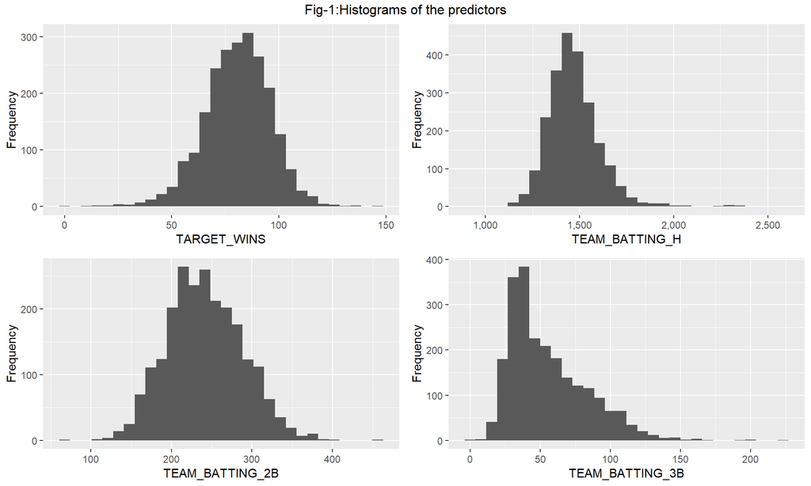

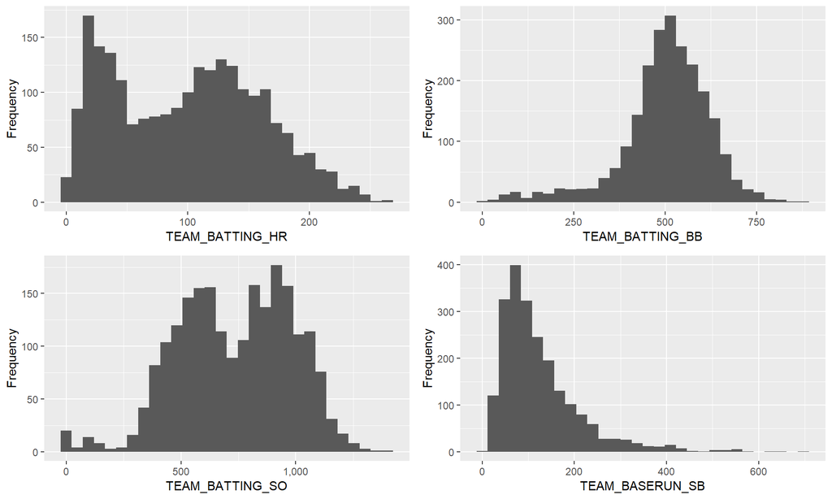

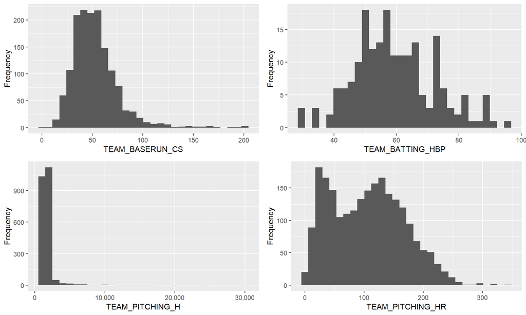

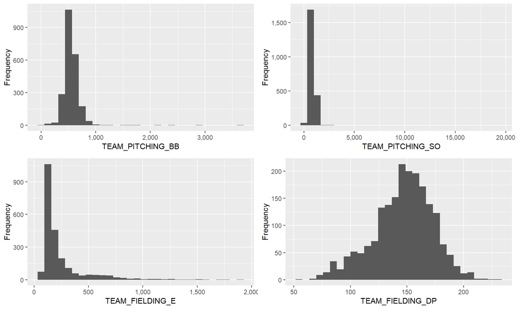

It is seen that most of the variables are approximately normally distributed with a few exceptions. It looks like *Hits allowed by pitchers*, *Walks allowed by pitchers*, *Fielding Errors* and *Pitching Strike Outs* are somewhat skewed to the right. We may need to transform them before fitting in the model.

The summaries and boxplots of the variables should help us understand the variables a bit more.

```
##   TARGET_WINS     TEAM_BATTING_H TEAM_BATTING_2B TEAM_BATTING_3B
##  Min.   :  0.00   Min.   : 891   Min.   : 69.0   Min.   :  0.00
##  1st Qu.: 71.00   1st Qu.:1383   1st Qu.:208.0   1st Qu.: 34.00
##  Median : 82.00   Median :1454   Median :238.0   Median : 47.00
##  Mean   : 80.79   Mean   :1469   Mean   :241.2   Mean   : 55.25
##  3rd Qu.: 92.00   3rd Qu.:1537   3rd Qu.:273.0   3rd Qu.: 72.00
##  Max.   :146.00   Max.   :2554   Max.   :458.0   Max.   :223.00
##
##  TEAM_BATTING_HR  TEAM_BATTING_BB TEAM_BATTING_SO  TEAM_BASERUN_SB
##  Min.   :  0.00   Min.   :  0.0   Min.   :   0.0   Min.   :  0.0
##  1st Qu.: 42.00   1st Qu.:451.0   1st Qu.: 548.0   1st Qu.: 66.0
##  Median :102.00   Median :512.0   Median : 750.0   Median :101.0
##  Mean   : 99.61   Mean   :501.6   Mean   : 735.6   Mean   :124.8
##  3rd Qu.:147.00   3rd Qu.:580.0   3rd Qu.: 930.0   3rd Qu.:156.0
##  Max.   :264.00   Max.   :878.0   Max.   :1399.0   Max.   :697.0
##                                   NA's   :102      NA's   :131
##  TEAM_BASERUN_CS TEAM_BATTING_HBP TEAM_PITCHING_H TEAM_PITCHING_HR
##  Min.   :  0.0   Min.   :29.00    Min.   : 1137   Min.   :  0.0
##  1st Qu.: 38.0   1st Qu.:50.50    1st Qu.: 1419   1st Qu.: 50.0
##  Median : 49.0   Median :58.00    Median : 1518   Median :107.0
##  Mean   : 52.8   Mean   :59.36    Mean   : 1779   Mean   :105.7
##  3rd Qu.: 62.0   3rd Qu.:67.00    3rd Qu.: 1682   3rd Qu.:150.0
##  Max.   :201.0   Max.   :95.00    Max.   :30132   Max.   :343.0
##  NA's   :772     NA's   :2085
##  TEAM_PITCHING_BB TEAM_PITCHING_SO  TEAM_FIELDING_E  TEAM_FIELDING_DP
##  Min.   :   0.0   Min.   :    0.0   Min.   :  65.0   Min.   : 52.0
##  1st Qu.: 476.0   1st Qu.:  615.0   1st Qu.: 127.0   1st Qu.:131.0
##  Median : 536.5   Median :  813.5   Median : 159.0   Median :149.0
##  Mean   : 553.0   Mean   :  817.7   Mean   : 246.5   Mean   :146.4
##  3rd Qu.: 611.0   3rd Qu.:  968.0   3rd Qu.: 249.2   3rd Qu.:164.0
##  Max.   :3645.0   Max.   :19278.0   Max.   :1898.0   Max.   :228.0
##                   NA's   :102                        NA's   :286
```

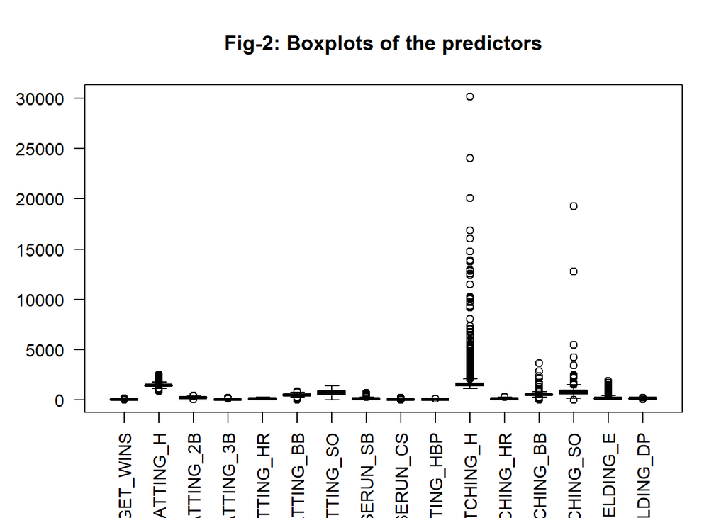

It looks like the *Hits allowed by pitchers* and *Pitching Strike Outs* variables are very widely spread and skewed to the right.

We will now check the data for missing values.

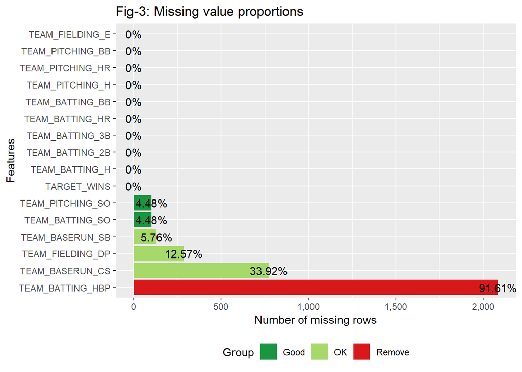

The above plot shows that there are 92% missing values in *Batters hit by pitch*. We are going to remove this variable from our model. The rest of the missing value proportions are not too great and we will impute the missing values to deal with them. Specifically, the missing values will be replaced by the mean if the variable is approximately normal, and they will be replaced by the median if they are skewed.

We will take log of the skewed variables in order to perform the analysis.

The boxplots below show the distributions of the variables after the transformations.

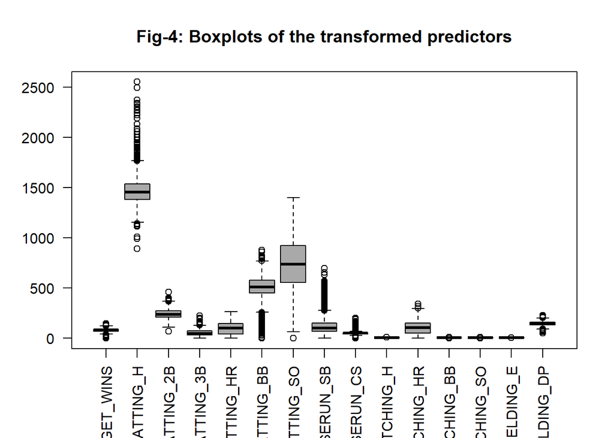

It looks like the variables are quite manageable now and we may fit the model.  
We now have a look at how the variables are correlated with the *Target wins* and within themselves in the following plots.

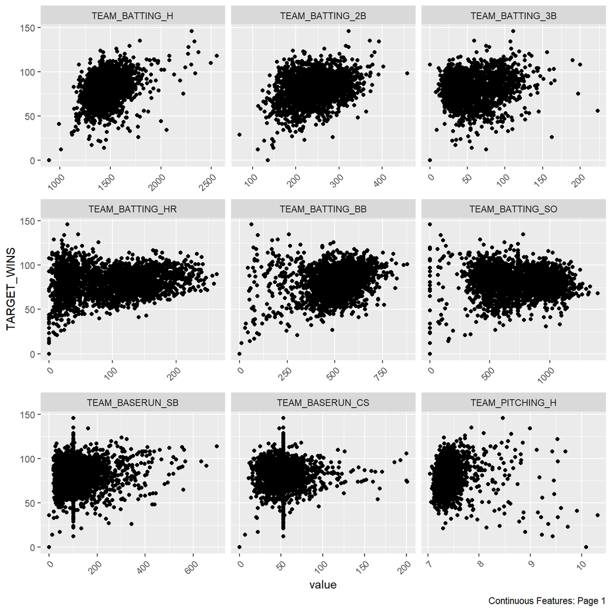

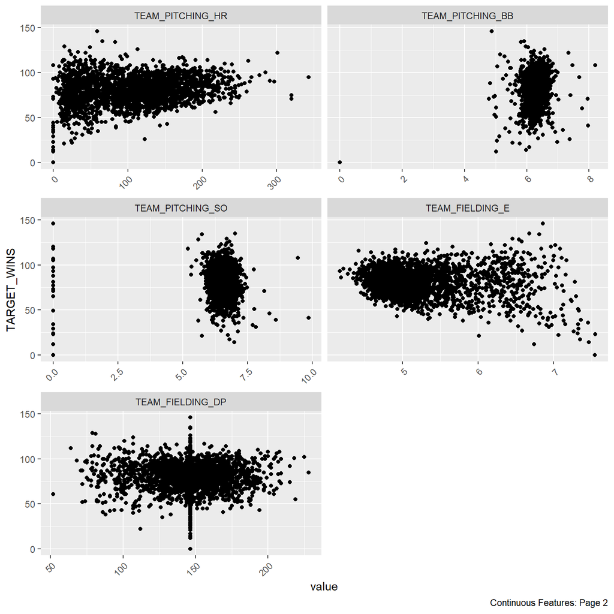

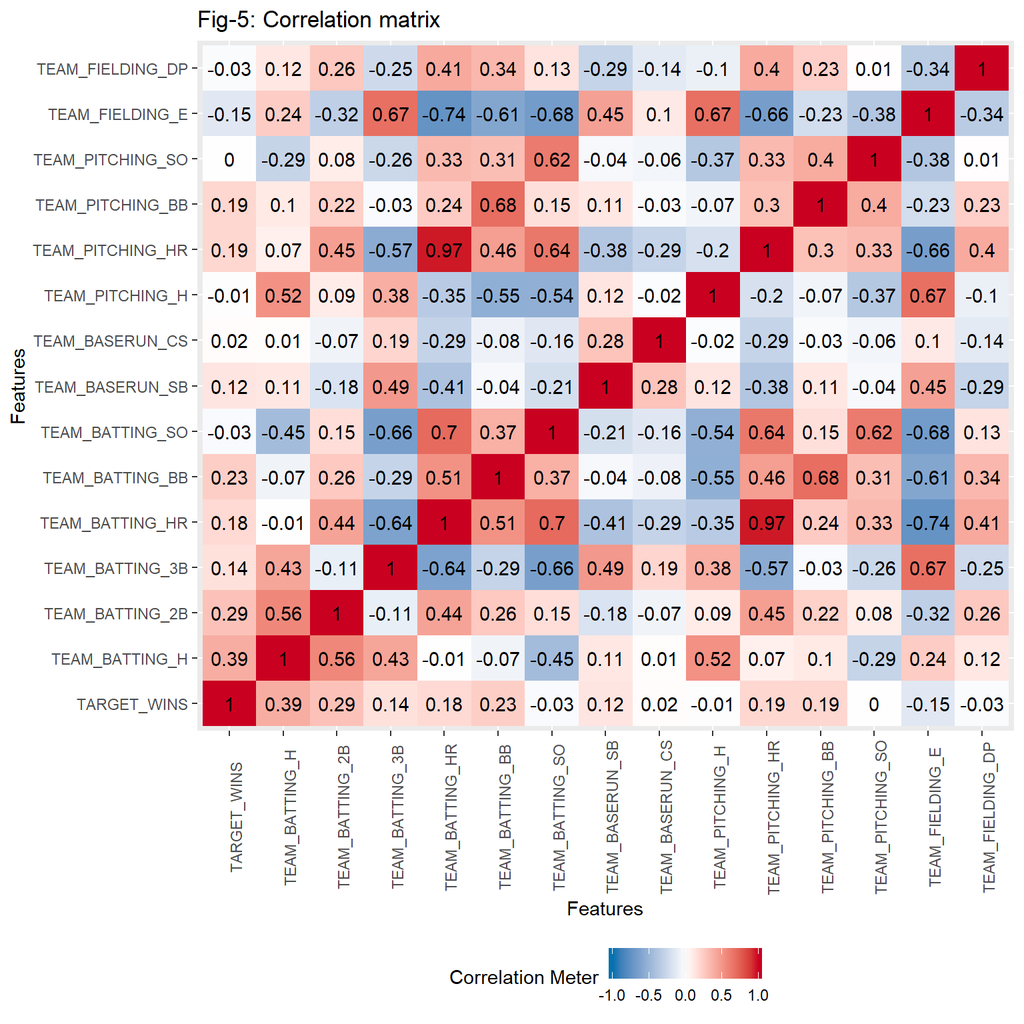

The correlation matrix shows that *Target wins* is the most correlated with *Base hits by batters(0.39)*. The rest of the correlations are rather tame. There are some highly correlated predictors and they are pretty intuitive. Such as *Fielding Errors* and *Hits allowed by pitchers* are likely to be correlated, since more allowed hits will lead to more fielding errors.

### Modeling Approach

We now fit a regression model with the *TARGET_WINS* as depenedent and the remaining variables as predictors. The *Backward* selection method is applied for the purpose.

```
##
## Call:
## lm(formula = TARGET_WINS ~ TEAM_BATTING_H + TEAM_BATTING_2B +
##     TEAM_BATTING_3B + TEAM_BATTING_HR + TEAM_BATTING_BB + TEAM_BATTING_SO +
##     TEAM_BASERUN_SB + TEAM_FIELDING_E + TEAM_FIELDING_DP, data = data)
##
## Residuals:
##     Min      1Q  Median      3Q     Max
## -60.920  -8.584   0.017   8.057  70.484
##
## Coefficients:
##                   Estimate Std. Error t value Pr(>|t|)
## (Intercept)      73.454569   7.497105   9.798  < 2e-16 ***
## TEAM_BATTING_H    0.045360   0.003605  12.584  < 2e-16 ***
## TEAM_BATTING_2B  -0.020924   0.009105  -2.298   0.0217 *
## TEAM_BATTING_3B   0.105929   0.016651   6.362 2.41e-10 ***
## TEAM_BATTING_HR   0.047381   0.009710   4.879 1.14e-06 ***
## TEAM_BATTING_BB   0.013870   0.003203   4.331 1.55e-05 ***
## TEAM_BATTING_SO  -0.005180   0.002271  -2.280   0.0227 *
## TEAM_BASERUN_SB   0.028346   0.004258   6.657 3.50e-11 ***
## TEAM_FIELDING_E  -9.948856   0.891310 -11.162  < 2e-16 ***
## TEAM_FIELDING_DP -0.130242   0.013008 -10.012  < 2e-16 ***
## ---
## Signif. codes:  0 '***' 0.001 '**' 0.01 '*' 0.05 '.' 0.1 ' ' 1
##
## Residual standard error: 13.08 on 2266 degrees of freedom
## Multiple R-squared:  0.3137, Adjusted R-squared:  0.311
## F-statistic: 115.1 on 9 and 2266 DF,  p-value: < 2.2e-16
```

The fitted model is:

TARGET_WINS = 73.45 + 0.045 TEAM_BATTING_H - 0.02 TEAM_BATTING_2B + 0.11 TEAM_BATTING_3B + 0.05 * TEAM_BATTING_HR + 0.01 TEAM_BATTING_BB - 0.005 TEAM_BATTING_SO + 0.03 TEAM_BASERUN_SB- 9.95 log(TEAM_FIELDING_E) - 0.13 TEAM_FIELDING_DP

The coefficient of *TEAM_BATTING_H* is .045 means that the *TARGET_WINS* increases by .045 unit one the average for an unit increase in *TEAM_BATTING_H* while the other factors remain constat. This goes with our expectation that wins should increase as the base hits by batters increase. Similar is the case with *TEAM_BATTING_3B*, *TEAM_BATTING_HR*, *TEAM_BATTING_BB* and *TEAM_BASERUN_SB*. Wins should increase as Triples, Walks, Homeruns and Stolen Bases increase. They all have a positive coefficient and are consistent with our expectations.

On the other hand, *TARGET_WINS* decreases by *9.95* units on the average as the log of *TEAM_FIELDING_E* increases by an unit, other factors remaining constant. This is also consistent with our natural way of thought because we all know *catches win matches!*. *TEAM_BATTING_SO* also have negative slopes which indicate that wins decrease as Batting Strike Outs increase. This is also in association with our expectation.

The odd ones in the model are *TEAM_BATTING_2B* and *TEAM_FIELDING_DP*, both of which should have a positive impact on wins but rather the model shows a negative association. This is incosistent with our expectations. The reason behind this abnormality is not known and further investigation is required to understand this anomaly.

The adjusted $R^2$ value is .31 which indicates that only 31% of the total variation in *TARGET_WINS* is explained by the model.

## TASK 2 - The Parsimony Model

We now have a look at the correlation between the predictors in the base model and *TARGET_WINS*

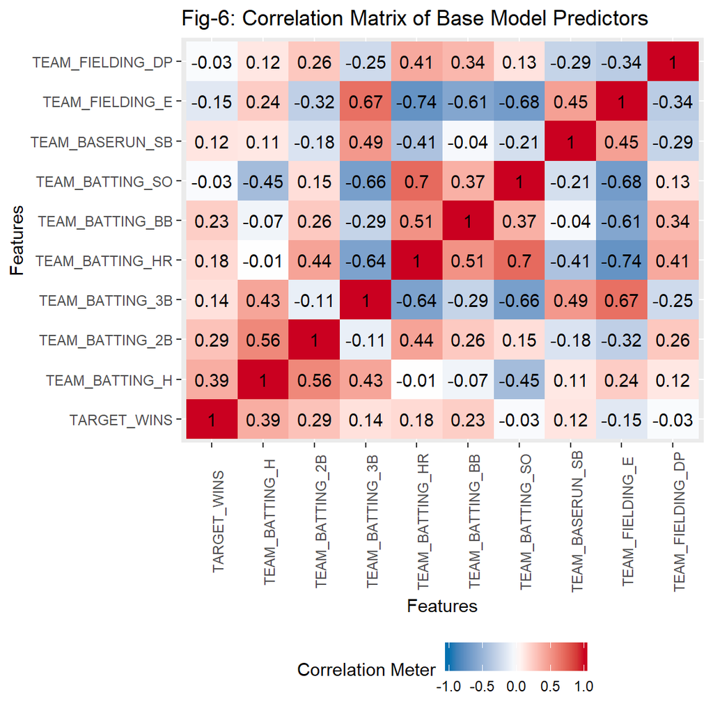

The correlations of *TEAM_BATTING_SO* and *TEAM_FIELDING_DP* seems quite low. So we are removing them and keeping the remaining 7 with higher correlations.

```
##
## Call:
## lm(formula = TARGET_WINS ~ ., data = parsimony_data)
##
## Residuals:
##     Min      1Q  Median      3Q     Max
## -63.600  -8.740  -0.066   8.474  66.738
##
## Coefficients:
##                  Estimate Std. Error t value Pr(>|t|)
## (Intercept)     53.541124   5.765987   9.286  < 2e-16 ***
## TEAM_BATTING_H   0.045814   0.003081  14.868  < 2e-16 ***
## TEAM_BATTING_2B -0.024672   0.008983  -2.746  0.00607 **
## TEAM_BATTING_3B  0.114386   0.016958   6.745 1.93e-11 ***
## TEAM_BATTING_HR  0.025019   0.008112   3.084  0.00207 **
## TEAM_BATTING_BB  0.008585   0.003142   2.732  0.00635 **
## TEAM_BASERUN_SB  0.033065   0.004032   8.201 3.94e-16 ***
## TEAM_FIELDING_E -9.739422   0.890063 -10.942  < 2e-16 ***
## ---
## Signif. codes:  0 '***' 0.001 '**' 0.01 '*' 0.05 '.' 0.1 ' ' 1
##
## Residual standard error: 13.36 on 2268 degrees of freedom
## Multiple R-squared:  0.2832, Adjusted R-squared:  0.281
## F-statistic:   128 on 7 and 2268 DF,  p-value: < 2.2e-16
```

The fitted model is:  
TARGET_WINS = 53.54 + 0.05 TEAM_BATTING_H - 0.02 TEAM_BATTING_2B + 0.11 TEAM_BATTING_3B + 0.03 TEAM_BATTING_HR + 0.01 TEAM_BATTING_BB + 0.03 TEAM_BASERUN_SB - 9.74 log(TEAM_FIELDING_E)

This regression is quite similar to the previous one. The signs of the coeffincients are similar and the values are quite close too. So they can be interpreted as was done previously. For example, the coefficient of *BATTING_BASERUN_SB* is 0.03 which indicates that the wins increase by 0.03 units on the average for an unit increase in *BATTING_BASERUN_SB* i.e. Stolen bases while other factors remain constat. This goes with our expectations.

The adjusted $R^2$ value of 0.28 indicates that only 28% of the variation in *TARGET_WINS* is explained by the parsimony model.

## TASK 3 - Contextual Modeling Approach

```
##
## Call:
## lm(formula = TARGET_WINS ~ ., data = data_3[data_3$MODERN ==
##     1, 1:15])
##
## Residuals:
##       Min        1Q    Median        3Q       Max
## -0.148881 -0.040300 -0.002126  0.042670  0.177289
##
## Coefficients:
##                   Estimate Std. Error t value Pr(>|t|)
## (Intercept)       0.636282   0.488843   1.302 0.195982
## TEAM_BATTING_H    0.079766   0.048133   1.657 0.100552
## TEAM_BATTING_2B   0.070650   0.038032   1.858 0.066102 .
## TEAM_BATTING_3B   0.163298   0.067867   2.406 0.017922 *
## TEAM_BATTING_HR  -1.655592   1.164409  -1.422 0.158126
## TEAM_BATTING_BB  -0.054418   0.097900  -0.556 0.579529
## TEAM_BATTING_SO  -0.137493   0.052598  -2.614 0.010302 *
## TEAM_BASERUN_SB   0.119861   0.030237   3.964 0.000137 ***
## TEAM_BASERUN_CS  -0.002505   0.043312  -0.058 0.953990
## TEAM_PITCHING_H  -0.505563   0.404355  -1.250 0.214052
## TEAM_PITCHING_HR  1.637872   1.114372   1.470 0.144701
## TEAM_PITCHING_BB  0.174623   0.290508   0.601 0.549110
## TEAM_PITCHING_SO  0.492836   0.186606   2.641 0.009565 **
## TEAM_FIELDING_E  -0.254455   0.039798  -6.394 4.94e-09 ***
## TEAM_FIELDING_DP -0.151078   0.059182  -2.553 0.012168 *
## ---
## Signif. codes:  0 '***' 0.001 '**' 0.01 '*' 0.05 '.' 0.1 ' ' 1
##
## Residual standard error: 0.07246 on 102 degrees of freedom
## Multiple R-squared:  0.5995, Adjusted R-squared:  0.5446
## F-statistic: 10.91 on 14 and 102 DF,  p-value: 9.824e-15
```

TARGET_WINS = .50, if MODERN = 0

## TASK 4 - Comparing Model Performance

Mean Absolute Deviations(MAD) of the different models.

|  | Base.Model | Mean.Model | Parsimony.Model | Contextual.Model | Random.Model |
| --- | --- | --- | --- | --- | --- |
| MAD | 10.15121 | 12.80327 | 12.5402 | 12.79923 | 41.58456 |

We observe from the table that the *Base Model* has the lowest Mean Absolute Deviation(MAD) and the *Random Model* has the highest. It should be noted that lesser the value of MAD, the better the fit. So, it may be safe to say that the *Base Model* fits the data the best of the five models considered. On the other hand, the *Random Model* has the worst performance.  
We also observe that the performances of the *Mean, Parsimony and Contextual* models are quite similar in that they have very close MAD values.

## TASK 5 - My Model

To sum up, we did the following in this project.

### Explarotary Data Analysis

We dissected the data, plotted the histograms of the variables and observed the relationship between the variables. We imputed the missing values by mean or median based on the spread of the variable. We also transformed the highly skewed variables logarithmically to be able to fit them in the models.

### Models

In particular, we compared five models and observed their performances on the data. We saw that the base model selected according to the *Backward Selection* method gave the best results.  
However we are selecting the Parsimony model as the *best model*. This was obtained by pruning the irrelevant variables of the *Base Model*. We select this model because it makes the most sense and also has a reasonable mean absolute deviation. **Our chosen model is:**

TARGET_WINS = 53.54 + 0.05 TEAM_BATTING_H - 0.02 TEAM_BATTING_2B+ 0.11 TEAM_BATTING_3B + 0.03 TEAM_BATTING_HR + 0.01 TEAM_BATTING_BB + 0.03 TEAM_BASERUN_SB- 9.74 log(TEAM_FIELDING_E)

In this model, all the coefficients are mostly intuitive and in association with our expectations. For example, the coefficients of *Hits, Walks and Stolen Bases* are positive. This mean that wins should increase as these variables increase. This makes sense. On the other hand, the coefficient of *Fielding Error* is negative which indicates that wins will decrease if Fielding errors increase. This is also very intuitive. The only anomaly in the model is the *Double Base Hits* which should have a positive coefficient but is negative in the model. Although the value of the coefficient is very small, .02, it is rather counter-intuitive. This may be due to the fact that the particular games in the dataset had seen more losses for teams with Doubles! This may happen in a real life situation. However, finding the exact reason would require further analysis which is beyond the scope of this project. We are retaining this variable in the model as of now.

This was the Moneyball Analysis project.

## Appendix: Codes

```r
library(DataExplorer)

data = read.csv('./MoneyBall.csv')
str(data)
data$INDEX = NULL

plot_histogram(data[,1:4], title = 'Fig-1:Histograms of the predictors')
plot_histogram(data[,5:8])
plot_histogram(data[,9:12])
plot_histogram(data[,13:16])

summary(data)
boxplot(data, las = 2, main = 'Fig-2: Boxplots of the predictors')
```

```r
plot_missing(data, title = 'Fig-3: Missing value proportions')

# treating missing values
# function to replace missing values by mean or median
replace_by_function = function(variable, FUN){
  variable[is.na(variable)] = FUN(variable, na.rm = T)
  return(variable)
}

data$TEAM_BATTING_SO = replace_by_function(data$TEAM_BATTING_SO, mean)
data$TEAM_PITCHING_SO = replace_by_function(data$TEAM_PITCHING_SO, median)
data$TEAM_BASERUN_SB = replace_by_function(data$TEAM_BASERUN_SB, median)
data$TEAM_FIELDING_DP = replace_by_function(data$TEAM_FIELDING_DP, mean)
data$TEAM_BASERUN_CS = replace_by_function(data$TEAM_BASERUN_CS, mean)

data$TEAM_BATTING_HBP = NULL

data$TEAM_PITCHING_H = log(data$TEAM_PITCHING_H)
data$TEAM_PITCHING_SO = log(data$TEAM_PITCHING_SO)
data$TEAM_PITCHING_BB = log(data$TEAM_PITCHING_BB)
data$TEAM_FIELDING_E = log(data$TEAM_FIELDING_E)

data$TEAM_PITCHING_BB[data$TEAM_PITCHING_BB == -Inf] = 0
data$TEAM_PITCHING_SO[data$TEAM_PITCHING_SO == -Inf] = 0


boxplot(data, col = 'dark grey', las = 2,
        main = 'Fig-4: Boxplots of the transformed predictors')
```

```r
plot_scatterplot(data, by = 'TARGET_WINS')
plot_correlation(data, title = 'Fig-5: Correlation matrix')

fit = lm(TARGET_WINS ~ ., data = data)
base_model = stepAIC(fit, direction = 'backward')
summary(base_model)
```

```r
parsimony_data = data[ , c(1:8, 14, 15)]
plot_correlation(parsimony_data, title = 'Fig-6: Correlation Matrix of Base Model Predictors')

parsimony_data = parsimony_data[ , -c(7, 10)]

fit2 = lm(TARGET_WINS ~ ., data = parsimony_data)
summary(fit2)
```

```r
## HELPER FUNCTIONS
# function that cleans the data, replaces Null values by mean/median
# takes log of the skewed variables.

clean_and_transform = function(data){
  # treating missing values
  # function to replace missing values by mean or median
  replace_by_function = function(variable, FUN){
    variable[is.na(variable)] = FUN(variable, na.rm = T)
    return(variable)
  }

  # replacing the missing values
  data$TEAM_BATTING_SO = replace_by_function(data$TEAM_BATTING_SO, mean)
  data$TEAM_PITCHING_SO = replace_by_function(data$TEAM_PITCHING_SO, median)
  data$TEAM_BASERUN_SB = replace_by_function(data$TEAM_BASERUN_SB, median)
  data$TEAM_FIELDING_DP = replace_by_function(data$TEAM_FIELDING_DP, mean)
  data$TEAM_BASERUN_CS = replace_by_function(data$TEAM_BASERUN_CS, mean)

  # transforming the variables logarithmically
  data$TEAM_PITCHING_H = log(data$TEAM_PITCHING_H)
  data$TEAM_PITCHING_SO = log(data$TEAM_PITCHING_SO)
  data$TEAM_PITCHING_BB = log(data$TEAM_PITCHING_BB)
  data$TEAM_FIELDING_E = log(data$TEAM_FIELDING_E)

  data$TEAM_PITCHING_BB[data$TEAM_PITCHING_BB == -Inf] = 0
  data$TEAM_PITCHING_SO[data$TEAM_PITCHING_SO == -Inf] = 0

  return(data)
}

# function that modernizes the data
modernize = function(data_3){
  data_3 = data_3/162

  # function that creates flags from ranges given.
  is_modern = function(x, lower, upper){
    flag = ifelse(x >= lower & x <= upper, 0, 1)
    return(flag)
  }

  # creating flag variables for each production variables
  data_3$modern_hits = is_modern(data_3$TEAM_BATTING_H, 8.25, 9.3)
  data_3$modern_2b = is_modern(data_3$TEAM_BATTING_2B, 1.65, 1.9)
  data_3$modern_3b = is_modern(data_3$TEAM_BATTING_3B, .15, .19)
  data_3$modern_hr = is_modern(data_3$TEAM_BATTING_HR, .85, 1.3)
  data_3$modern_bb = is_modern(data_3$TEAM_BATTING_BB, 2.88, 3.6)
  data_3$modern_so = is_modern(data_3$TEAM_BATTING_SO, 6.4, 8.9)
  data_3$modern_sb = is_modern(data_3$TEAM_BASERUN_SB, .5, .7)
  data_3$modern_cs = is_modern(data_3$TEAM_BASERUN_CS, .16, .3)
  data_3$modern_e = is_modern(data_3$TEAM_FIELDING_E, .55, .7)
  data_3$modern_dp = is_modern(data_3$TEAM_FIELDING_DP, .85, .95)

  # creating the MODERN variable
  data_3$MODERN = ifelse(rowSums(data_3[ , 20:29]) == 10, 1, 0)

  return(data_3$MODERN)
}
```

```r
data_3 = read.csv('./MoneyBall.csv')
data_3$INDEX = NULL
data_3$TEAM_BATTING_HBP = NULL
data_3 = data_3/162

data_3 = clean_and_transform(data_3)

# function that creates flags from ranges given.
is_modern = function(x, lower, upper){
  flag = ifelse(x >= lower & x <= upper, 0, 1)
  return(flag)
}

# creating flag variables for each production variables
data_3$modern_hits = is_modern(data_3$TEAM_BATTING_H, 8.25, 9.3)
data_3$modern_2b = is_modern(data_3$TEAM_BATTING_2B, 1.65, 1.9)
data_3$modern_3b = is_modern(data_3$TEAM_BATTING_3B, .15, .19)
data_3$modern_hr = is_modern(data_3$TEAM_BATTING_HR, .85, 1.3)
data_3$modern_bb = is_modern(data_3$TEAM_BATTING_BB, 2.88, 3.6)
data_3$modern_so = is_modern(data_3$TEAM_BATTING_SO, 6.4, 8.9)
data_3$modern_sb = is_modern(data_3$TEAM_BASERUN_SB, .5, .7)
data_3$modern_cs = is_modern(data_3$TEAM_BASERUN_CS, .16, .3)
data_3$modern_e = is_modern(data_3$TEAM_FIELDING_E, .55, .7)
data_3$modern_dp = is_modern(data_3$TEAM_FIELDING_DP, .85, .95)

# creating the MODERN variable
data_3$MODERN = ifelse(rowSums(data_3[ , 16:25]) == 10, 1, 0)

# fitting the regression
fit3 = lm(TARGET_WINS ~., data = data_3[data_3$MODERN == 1, 1:15])

summary(fit3)

mean_Y = mean(data_3$TARGET_WINS[data_3$MODERN == 0])

## ranges used, taken from https://www.baseball-reference.com/

#batting _hits = 8.25, 9.3
#batting_2B = 1.65, 1.9
#batting_3B = .15, .19
#batting_hr = .85, 1.3
#batting_bb = 2.88, 3.6
#batting_so = 6.4, 8.9
#baserun_sb = .5, .7
#baserun_cs = .16, .3
#fielding_e = .55, .7
#fielding_dp = .85, .95
```

```r
data = read.csv('./MoneyBall.csv')

mean_y = mean(data$TARGET_WINS)
max_y = max(data$TARGET_WINS)
min_y = min(data$TARGET_WINS)

export_data = read.csv('./MoneyBall_EXPORT.csv')
n = nrow(export_data)
export_data$Y_MEAN = mean_y
export_data$Y_RANDOM = runif(n, min_y, max_y)
export_data = clean_and_transform(export_data)
attach(export_data)
export_data$Y_BASE = 73.45 + 0.045 * TEAM_BATTING_H -
  0.02 * TEAM_BATTING_2B+ 0.11 * TEAM_BATTING_3B +
  0.05 * TEAM_BATTING_HR + 0.01 * TEAM_BATTING_BB-
  0.005*  TEAM_BATTING_SO + 0.03 * TEAM_BASERUN_SB-
  9.95 * TEAM_FIELDING_E - 0.13 * TEAM_FIELDING_DP

export_data$Y_PARSIMONY = 53.54 + 0.05 * TEAM_BATTING_H -
  0.02 * TEAM_BATTING_2B+ 0.11 * TEAM_BATTING_3B +
  0.03 * TEAM_BATTING_HR + 0.01 * TEAM_BATTING_BB +
  0.03 * TEAM_BASERUN_SB- 9.74 * TEAM_FIELDING_E

export_data$MODERN = modernize(export_data)

attach(export_data)
export_data$Y_CONTEXTUAL = ifelse(MODERN == 1, 0.64 + 0.07 * TEAM_BATTING_2B/162+ 0.16 * TEAM_BATTING_3B/162 -
  0.14*  TEAM_BATTING_SO/162 + 0.49* TEAM_PITCHING_SO/162 +
  .11 * TEAM_BASERUN_SB/162- .25 * TEAM_FIELDING_E/162 -
  0.15* TEAM_FIELDING_DP/162, .50)
export_data$Y_CONTEXTUAL = export_data$Y_CONTEXTUAL * 162

attach(export_data)
actual = read.csv('./MoneyBall_ACTUAL.csv')

model_compare = data.frame('Y_ACTUAL' = actual$Y_Actual, Y_BASE, Y_CONTEXTUAL, Y_MEAN, Y_PARSIMONY, Y_RANDOM)

Base = mean(abs(model_compare$Y_ACTUAL - model_compare$Y_BASE))
Mean = mean(abs(model_compare$Y_ACTUAL - model_compare$Y_MEAN))
Parsimony = mean(abs(model_compare$Y_ACTUAL - model_compare$Y_PARSIMONY))
Contextual = mean(abs(model_compare$Y_ACTUAL - model_compare$Y_CONTEXTUAL))
Random = mean(abs(model_compare$Y_ACTUAL - model_compare$Y_RANDOM))
```

```r
library(kableExtra)
dt = data.frame('Base Model' = Base, 'Mean Model' = Mean,
                'Parsimony Model' = Parsimony,
                'Contextual Model' = Contextual,
                'Random Model' = Random,
                row.names = 'MAD')
kable(dt, format = 'latex', booktabs = T,
      caption = 'Mean Absolute Deviations(MAD)
      of the different models.') %>%
  kable_styling(latex_options = c("striped", "hold_position"))
```

```r
export_data = read.csv('./MoneyBall_EXPORT.csv')
export_data = clean_and_transform(export_data)
attach(export_data)
Y_WATCHER = 53.54 + 0.05 * TEAM_BATTING_H -
  0.02 * TEAM_BATTING_2B+ 0.11 * TEAM_BATTING_3B +
  0.03 * TEAM_BATTING_HR + 0.01 * TEAM_BATTING_BB +
  0.03 * TEAM_BASERUN_SB- 9.74 * TEAM_FIELDING_E

to_export = data.frame('INDEX' = export_data[, 1], Y_WATCHER)
write.csv(to_export, file = 'Project1_Watcher.csv', row.names = F)
```